# Лабораторная Работа №15

Динамическая маршрутизация

Козлов В.П.

Российский университет дружбы народов им. Патриса Лумумбы, Москва, Россия

## Докладчик

- Козлов Всеволод Павлович
- НФИбд-02-22
- Российский университет дружбы народов
- [1132226428@pfur.ru]

# Выполнение лабораторной работы

## Цель работы

Настроить динамическую маршрутизацию между территориями организации.

## Задание

1. Настроить динамическую маршрутизацию по протоколу OSPF на маршрутизаторах msk-donskaya-gw-1, msk-q42-gw-1, msk-hostel-gw-1, sch-sochi-gw-1.
2. Настроить связь сети квартала 42 в Москве с сетью филиала в г. Сочи напрямую.
3. В режиме симуляции отследить движение пакета ICMP с ноутбука администратора сети на Донской в Москве (Laptop-PT admin) до компьютера пользователя в филиале в г. Сочи pc-sochi-1.
4. На коммутаторе провайдера отключить временно vlan 6 и в режиме симуляции убедиться в изменении маршрута прохождения пакета ICMP с ноутбука администратора сети на Донской в Москве (Laptop-PT admin) до компьютера пользователя в филиале в г. Сочи pc-sochi-1.
5. На коммутаторе провайдера восстановить vlan 6 и в режиме симуляции убедиться в изменении маршрута прохождения пакета ICMP с ноутбука администратора сети на Донской в Москве (Laptop-PT admin) до компьютера пользователя в филиале в г. Сочи pc-sochi-1.
6. При выполнении работы необходимо учитывать соглашение об именовании.

## Настройка маршрутизатора msk-donskaya-gw-1

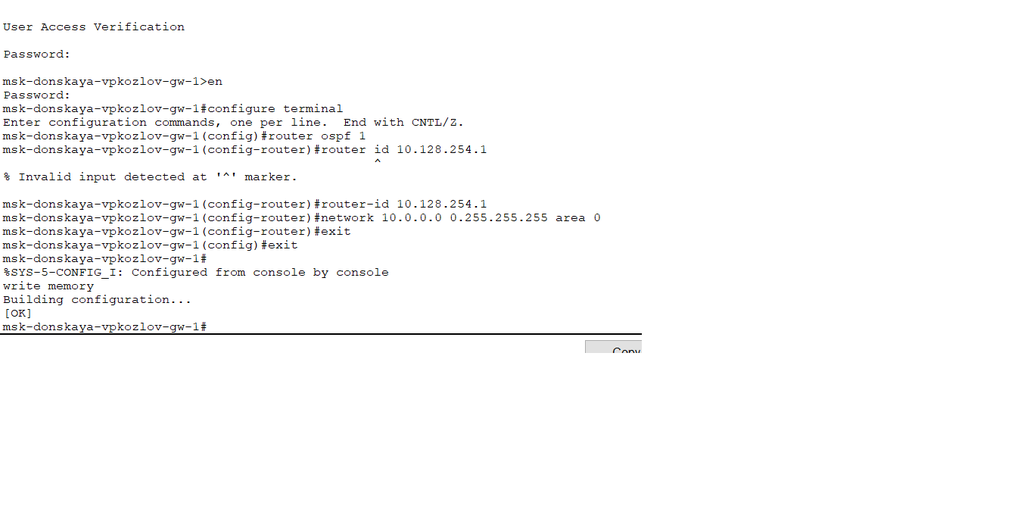

Настройка маршрутизатора msk-donskaya-gw-1

## Проверил состояние OSPF

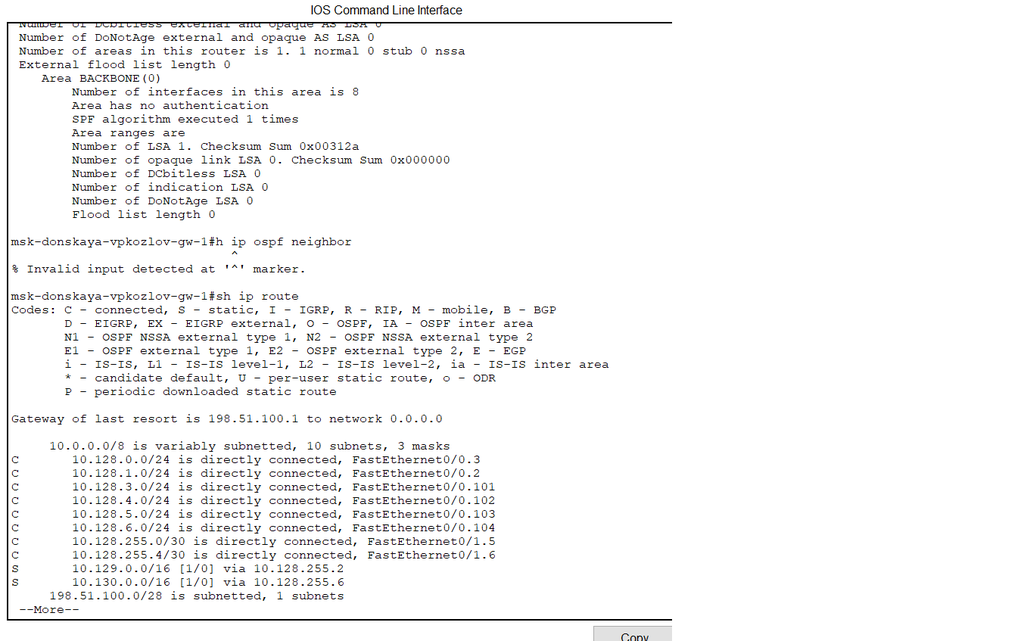

Состояние OSPF

## Настройка маршрутизатора msk-q42-gw-1

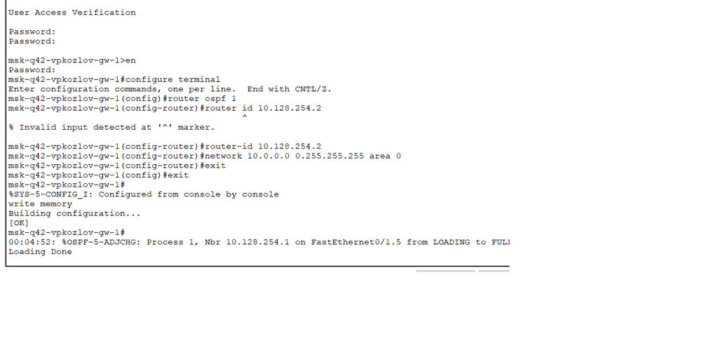

Настройка маршрутизатора msk-q42-gw-1

## Настройка маршрутизирующего коммутатора msk-hostel-gw-1

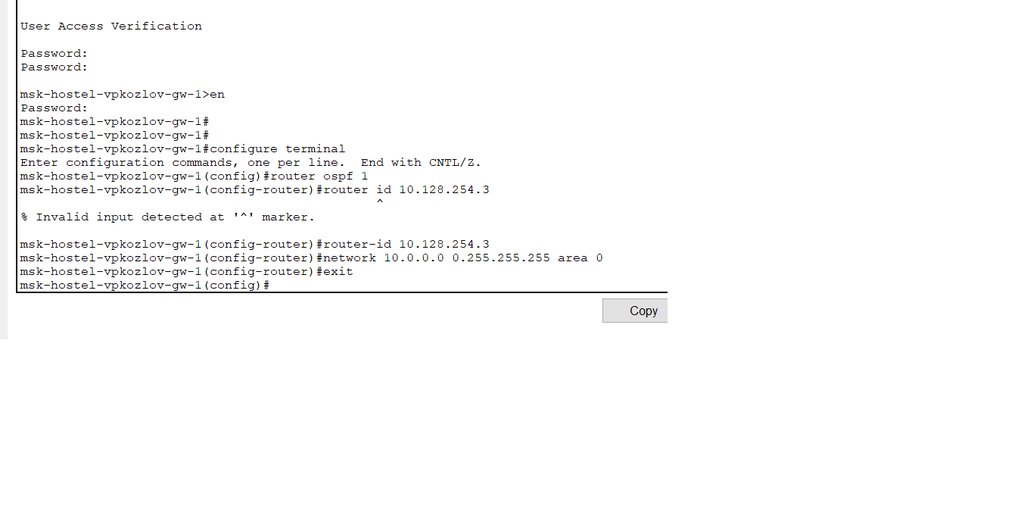

Настройка маршрутизирующего коммутатора msk-hostel-gw-1

## Настройка маршрутизатора sch-sochi-gw-1

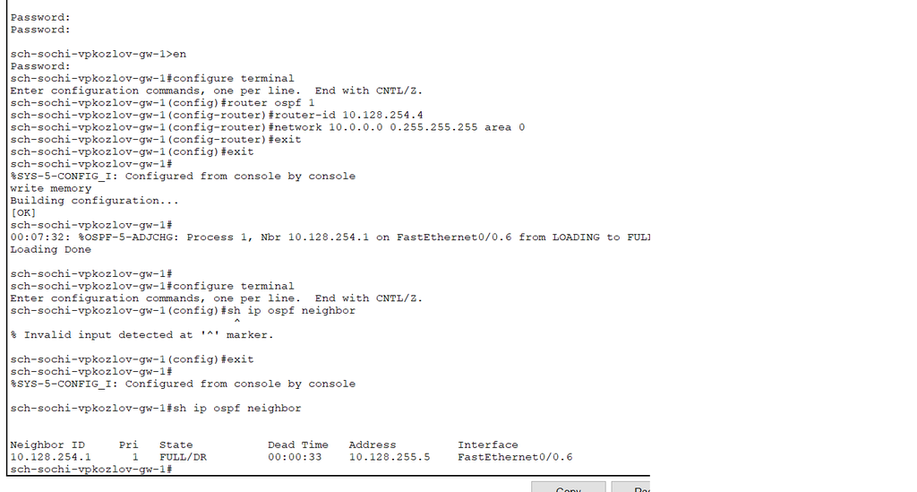

Настройка маршрутизатора sch-sochi-gw-1

## Настройка интерфейсов коммутатора provider-sw-1

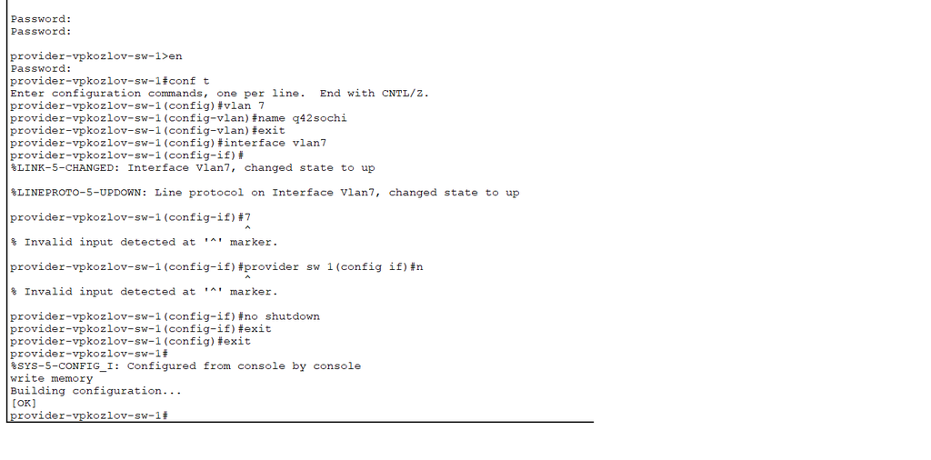

Настройка интерфейсов коммутатора provider-sw-1

## Настройка маршрутизатора msk-q42-gw-1

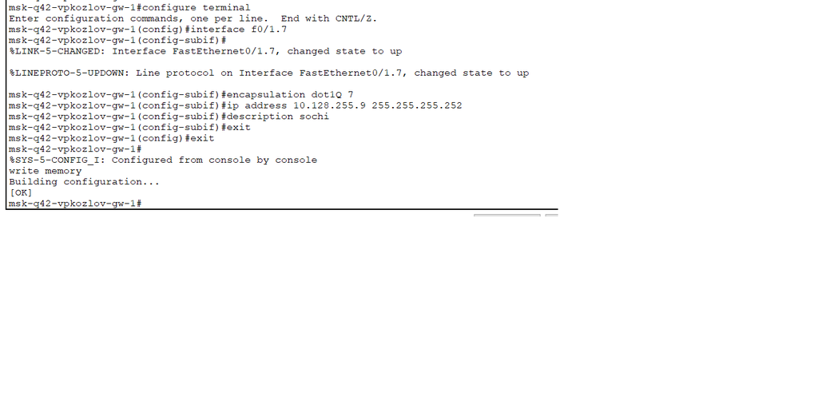

Настройка маршрутизатора msk-q42-gw-1

## Настройка коммутатора sch-sochi-sw-1

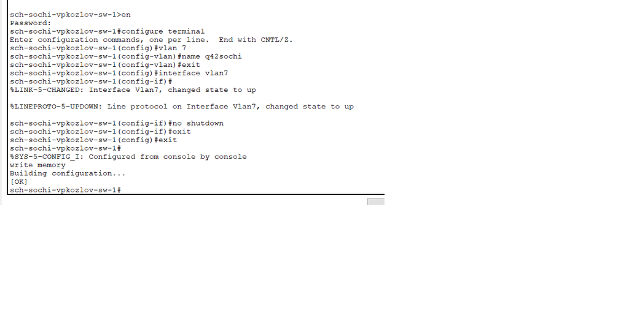

Настройка коммутатора sch-sochi-sw-1

## Настройка маршрутизатора sch-sochi-gw-1

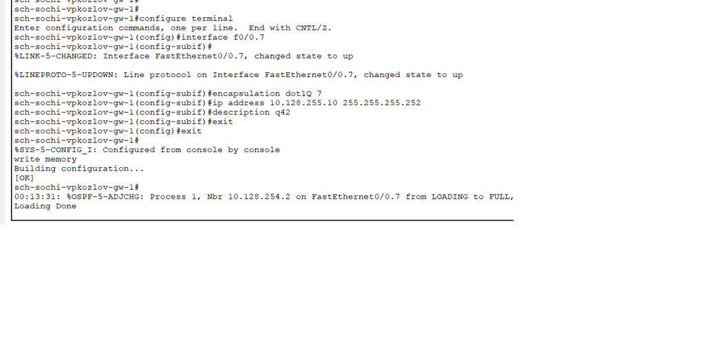

Настройка маршрутизатора sch-sochi-gw-1

## Движение пакета ICMP от администратора нп ПК в 42 квартал

[figure not shown]

Движение пакета ICMP от администратора нп ПК в 42 квартал

## Пингование

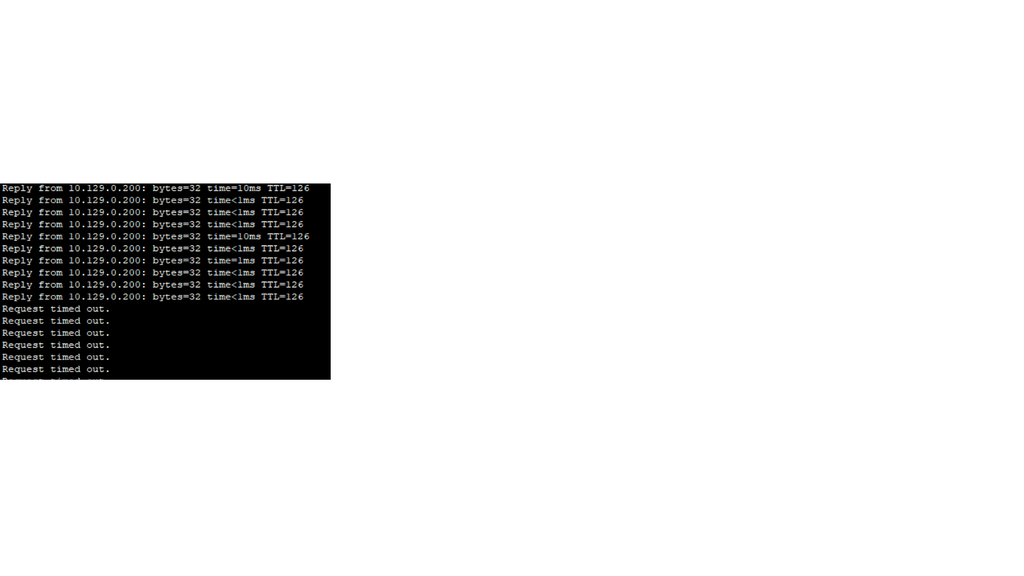

## Выводы

Настроить динамическую маршрутизацию между территориями организации.